# Assignment3

sl3641

October 20, 2014

For this assignment, I am comparing responses from

1. Wave 6 (2010)
2. Wave 5 (2005) of the World Values Survey administered in South Korea.

References and links can be found at the end of this document.

**Research Question**  
Specifically, I wanted to see how attitudes towards the importance of the economy (versus other national priorities) have changed over time. My hypothesis is that as South Korea’s economic conditions improve over time, individuals will place more importance on other values such as a more humane society.

The relevant question from the World Values Survey is below:

People sometimes talk about what the aims of this country should be for the next ten years. On this card are listed some of the goals which different people would give top priority. Would you please say which of these you, yourself, consider the most important? …

A stable economy

Progress toward a less impersonal and more humane society

Progress toward a society in which ideas count more than money

The fight against crime

This is the script that reads, transforms, and prepares data for the graph.  
The description of variables is in the comments.

```r
setwd("~/Documents/qmssviz_other/Assignment3")
wv5 <- read.csv("WV5_Data_South_Korea.csv")   # read Wave 5 data
wv6 <- read.csv("WV6_Data_South_Korea.csv")   # read Wave 6 data

econwv5 <- wv5[,c("V1", "V73")]      # extract year and question of interest
colnames(econwv5) <- (c("wave", "imp1"))     # rename variables
econwv6 <- wv6[,c("V1", "V64")]      # extract year and question of interest
colnames(econwv6) <- (c("wave", "imp1"))     # rename variables

all <- rbind(econwv5, econwv6)    # combine data from wv5 and wv6

# create a new variable, recoding the responses that had been entered as numbers back into text format
all$label <- ifelse(all$imp1==1, "stable economy",
                    ifelse(all$imp1==2, "more humane society",
                           ifelse(all$imp1==3, "ideas more than money",
                                  ifelse(all$imp1==4, "fight against crime", "no answer"))))

# calculate total number of responses by answer choice and wave
summ <- as.data.frame(table(all$wave, all$label))

# rename variables in dataframe generated by using table() function above
colnames(summ) <- c("wave", "question", "freq")

# calculate proportion of respondents who selected a particular response
summ$percent <- summ$freq/1200 * 100

# generate variable recoding wave into year
summ$year <- ifelse(summ$wave==5, "2005", "2010")
```

This is the final dataset that we are using for the graph

```r
summ
```

```
##    wave              question freq  percent year
## 1     5   fight against crime   32  2.66667 2005
## 2     6   fight against crime   72  6.00000 2010
## 3     5 ideas more than money   51  4.25000 2005
## 4     6 ideas more than money   54  4.50000 2010
## 5     5   more humane society  234 19.50000 2005
## 6     6   more humane society  314 26.16667 2010
## 7     5             no answer    1  0.08333 2005
## 8     6             no answer    3  0.25000 2010
## 9     5        stable economy  882 73.50000 2005
## 10    6        stable economy  757 63.08333 2010
```

This creates the graph.

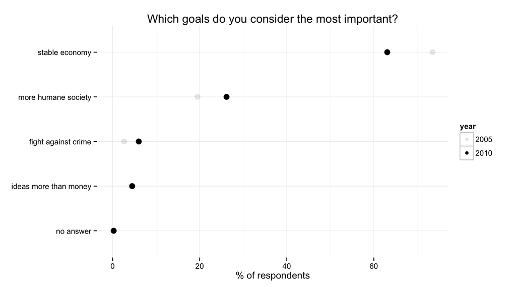

```r
require("ggplot2")
ggplot(summ, aes(x=question, y=percent)) +
  geom_point(aes(size=2, alpha=year)) +
  coord_flip() +
  theme_bw() +
  theme(axis.title.y = element_blank(), panel.border=element_blank()) +
  scale_size(guide="none") +
  ylab("% of respondents") +
  ggtitle("Which goals do you consider the most important?") +
  scale_x_discrete(limits=c("no answer", "ideas more than money",
                            "fight against crime", "more humane society", "stable economy"))
```

Below are expressive fantasy function calls describing how I read, transformed, and prepared the data for the graph.

```r
wave5 <- read.csv("filepath")   # read Wave 5 data
wave6 <- read.csv("filepath")   # read Wave 6 data

wave5 <- getVariables(wave5, listOfVariables)  # extract variables of interest (from Wave 5)
wave6 <- getVariables(wave6, listOfVariables)  # extract variables of interest (from Wave 6)

renameValues(wave5, wave6, nameOfVariables)  # rename variables in both wave5 and wave6 dataframes

all <- rbind(econwv5, econwv6)    # combine data from wv5 and wv6

# add labels to responses which were coded as numbers
all <- recodeResponses(variables, labels)

# produce final dataset with frequency and % counts
final <- makeFinalDataSet(year, question)

# generate final dot chart
visualization <- makeFinalChart(question, percent, ...)
```

This is my attempt at writing a function that renames the columns (i.e. variables) for the two datasets, combines them, and then produces the combined dataset.

```r
variablenames <- c("wave", "Q1")

renameAndCombine <- function(econwv5, econwv6, variablenames){
  colnames(econwv5) <- variablenames
  colnames(econwv6) <- variablenames
  all <- rbind(econwv5, econwv6)
  assign("all", all, envir=globalenv())
}

# Testing my function to see if it produces 'all' dataset
renameAndCombine(econwv5, econwv6, variablenames)
```

References:

http://www.worldvaluessurvey.org/WVSDocumentationWV6.jsp

Title: South Korea 2010

Field-work dates: 27-02-2010 to 08-03-2010

Institute: Korean Social Science Data Center(KSDC)

PI Prof Soo Young Auh

http://www.worldvaluessurvey.org/WVSDocumentationWV5.jsp

Title: South Korea 2005

Field-work dates: 01-12-2005 to 15-12-2005

Institute: Korean Social Science Data Center(KSDC)

PI Prof Soo Young Auh